# Bayesian Hierarchical true prevalence estimation

Eleftherios Meletis & Aurélien Madouasse

2022-03-23

# Objectives of this Section

- Explain Bayes’ theorem | Bayesian Inference
- Why apparent prevalence is different than true prevalence?
- Apply a simple apparent & true prevalence estimation model
- Understand the full hierarchical model

# Bayes’ theorem

- P(A|B): Prob of event A occurring given that B is true - Posterior probability
- P(B|A): Prob of event B occurring given that A is true - Likelihood ~ function of A
- P(A): Prob of event A occurring - Prior probability
- P(B): Prob of event B occurring - Marginal probability ~ sum over all possible values of A

# What we usually see/use

- P($\theta$): Prior probability of parameter(s) of interest;
- P(y/$\theta$): Likelihood of the data given the parameters value(s)
- P($\theta$|y): Posterior probability of parameter(s) of interest given the data and the prior

# Bayesian Inference - Summary & Example

To estimate the posterior distribution P($\theta$|y) we need to:

- *Specify* the **Prior distribution**: P($\theta$)
- *Define* the **Likelihood** of the data: P(y|$\theta$)

### Example: Bayesian apparent prevalence (ap) estimation

y out of n individuals test positive. Estimate the apparent prevalence.

Parameter of interest: ap$\epsilon$[0,1]

Data: n tested, y positive

- Prior distribution for ap: ap ~ Beta(a,b)
- Likelihood: y ~ Binomial(n,ap)

# Let’s write our first JAGS model

```r
ap_model <-
'model {

  # Define likelihood distribution of the data
  # JAGS Binomial distribution Arguments: p, n

  y ~ dbin(ap,n)

  # Specify prior distribution for par of interest
  # Uniform (non-informative) prior distribution
  ap ~ dbeta(1,1)

  #data# n, y
  #monitor# ap
  #inits# ap
}
'
```

# Let’s run our first JAGS model

```r
# Call JAGS
library(runjags)

# Provide Data
n = 4072
y = 1210

# Initial values for par of interest
ap <- list(chain1=0.05, chain2=0.95)
```

```r
# Run the model
results <- run.jags(ap_model, n.chains=2,
                    burnin=5000, sample=10000)
```

# View results

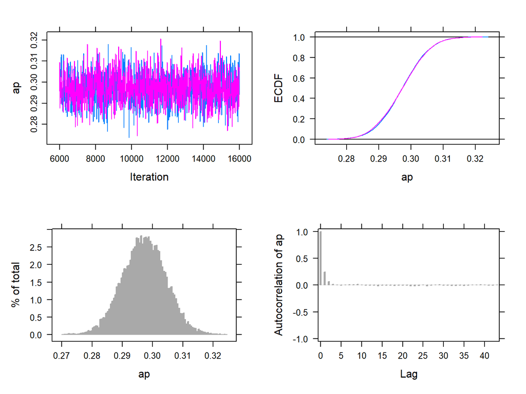

# Example: Bayesian true prevalence (tp) estimation

Assuming the absence of a perfect test we do not know how many individuals are truly positive/negative.

Instead we know that *n* individuals are tested with an imperfect test and *y* have a positive result.

# Create a JAGS model for true prevalence estimation

Parameters of interest:

- tp$\epsilon$[0,1]
- Se$\epsilon$[0,1]
- Sp$\epsilon$[0,1]

Prior distributions

- tp ~ dbeta(1,1)
- Se ~ dbeta(25.4, 3.4)
- Sp ~ dbeta(95, 5)

Data: n tested, y positive

- Likelihood: y ~ Binomial(n,ap), ap = tp * Se + (1 - tp) * (1 - Sp)

# Write JAGS model

```r
tp_model <-
'model {

  y ~ dbin(ap,n)
  ap <- tp*Se + (1-tp)*(1-Sp)

  # Uniform (non-informative) prior distribution
  tp ~ dbeta(1,1)
  # Informative priors for Se and Sp
  Se ~ dbeta(25.4, 3.4)
  Sp ~ dbeta(95, 5)

  #data# n, y
  #monitor# tp, Se, Sp
  #inits# tp, Se, Sp
}
'
```

# Let’s run our JAGS model

```r
# Call JAGS
library(runjags)

# Provide Data
n = 4072
y = 1210

# Initial values for pars of interest
tp <- list(chain1=0.05, chain2=0.95)
Se <- list(chain1=0.05, chain2=0.95)
Sp <- list(chain1=0.05, chain2=0.95)
```

```r
# Run the model
results <- run.jags(tp_model, n.chains=2,
                    burnin=5000, sample=10000)
```

# View results

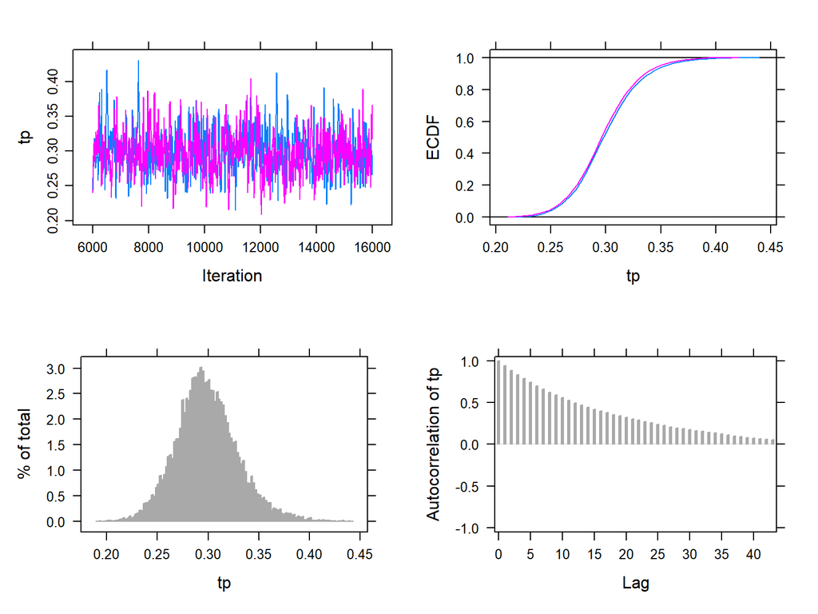

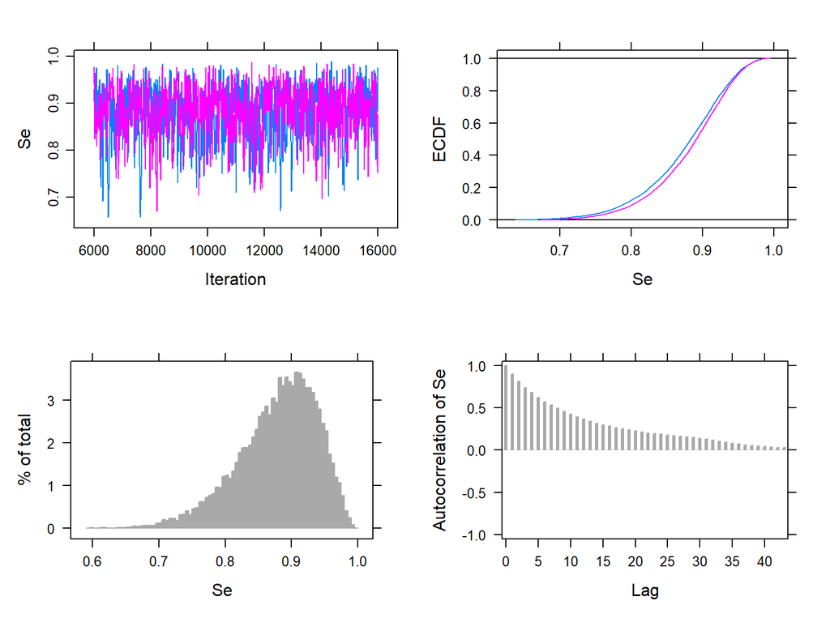

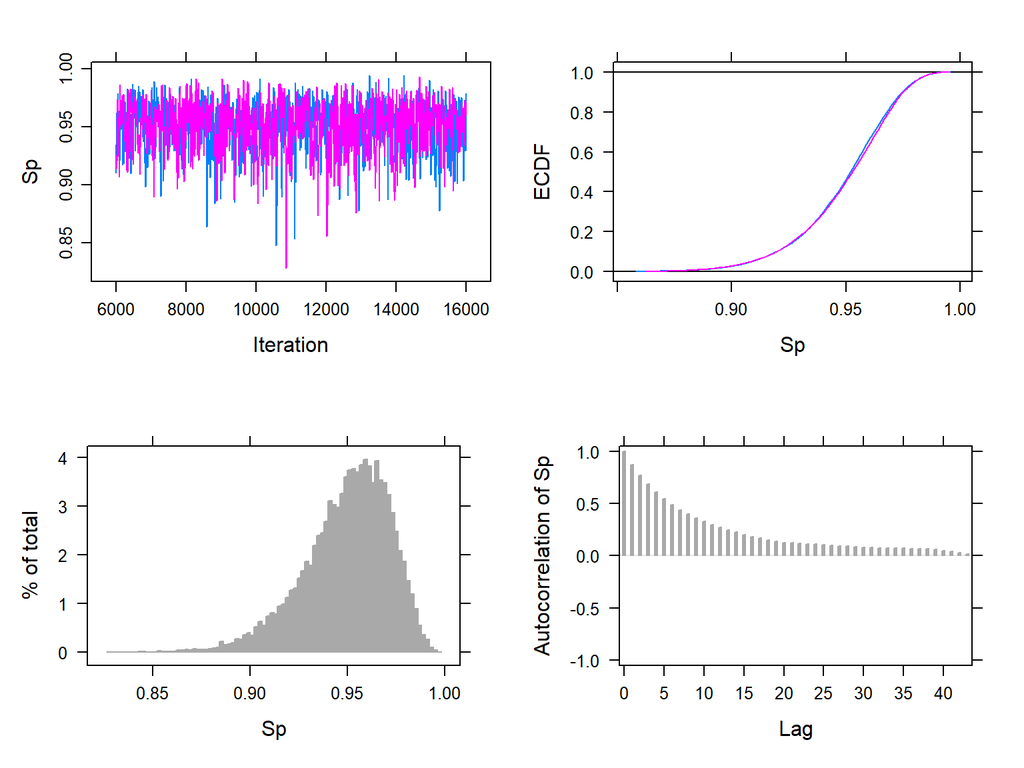

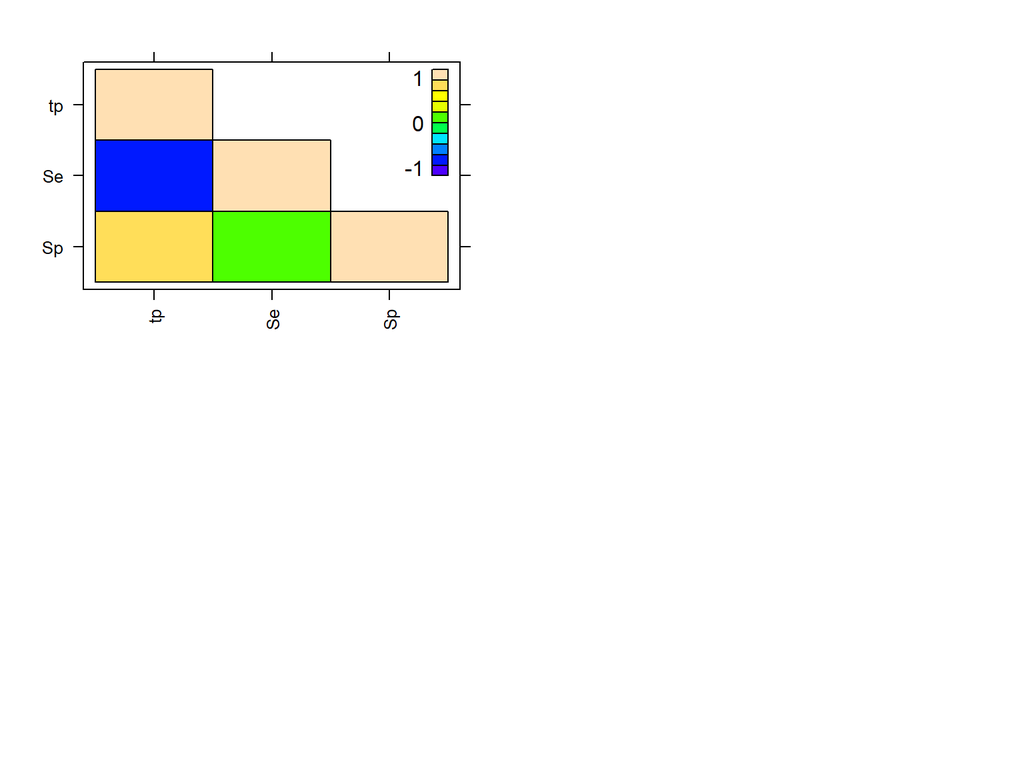

# Bayesian hierarchical true prevalence estimation

### Model breakdown

Captures the population structure and is divided in three parts that describe distribution of disease:

- Within herds which are
- Within regions in the
- Country under consideration

# Full Model Figure

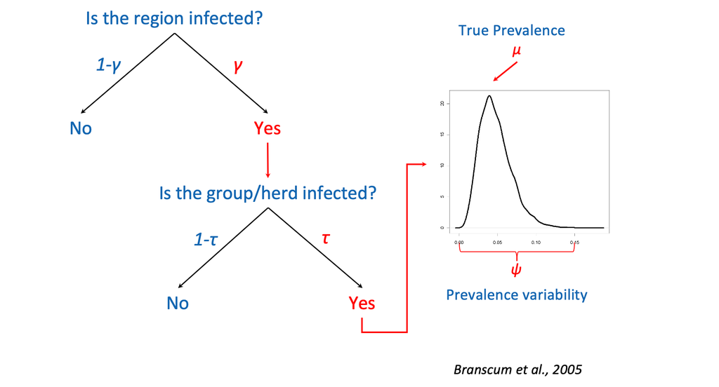

# Model outputs

- Animal-level true prevalence of infection within infected herds
- Herd-level prevalence of infection in the region
- Region-level prevalence of infection
- Probability that the whole country is free from infection
- Probability of freedom from infection at each level of hierarchy
- Probability that infection does not exceed a pre-specified critical level (e.g. 5%) in a specific region

# Run the model with JAGS

The model and the data are already saved in the Section’s folder.

Let’s load and view the data.

```
##   region y   n
## 1      1 1 107
## 2      1 1  92
## 3      1 1 114
## 4      1 1 121
## 5      1 1 105
## 6      1 1  92
```

# Run the model

# Visualise results (I)

### ap & tp in each herd

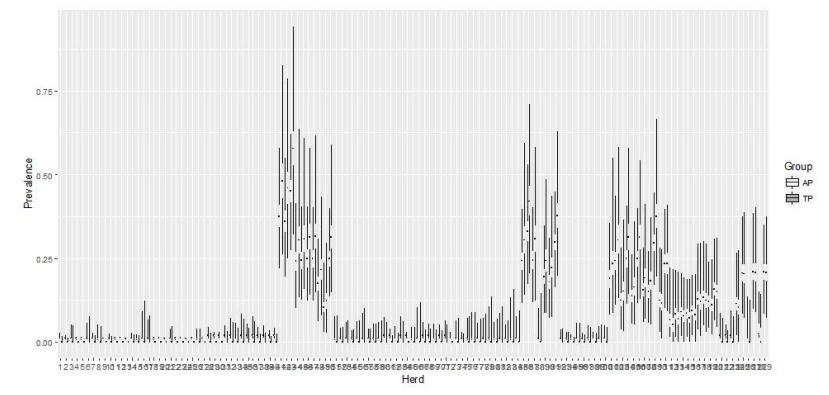

# Visualise results (II)

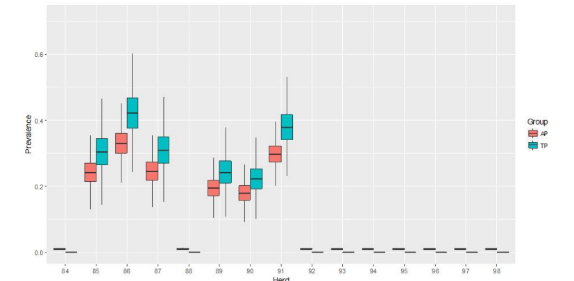

# Visualise results (III)

### Herd-level prevalence in each region

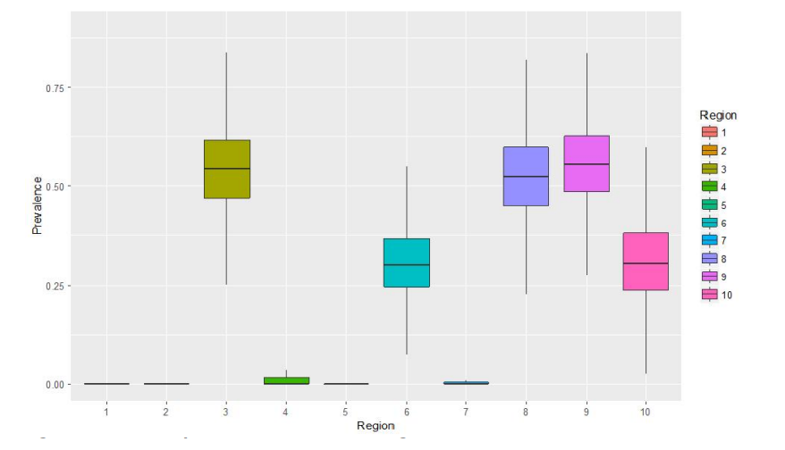

# Conclusions

- Questions???

Suggested literature

- Kostoulas et al, (2019) Harmonisation Of Transmissible disease Interpretation in the EU HOTLINE
- Branscum et al, (2004) Bayesian modeling of animal- and herd-level prevalences